# cbp v. salty coastlines

I got the soil salinity data here, from the [ISRIC Data Hub.](https://data.isric.org/geonetwork/srv/eng/catalog.search#/metadata/ca880bd4-cff8-11e9-8046-0cc47adaa92c)

The *Capsella bursa-pastoris* occurences were downloaded from iNaturalist.

### iNaturalist data and global soil chemical profiles

```r
# read inaturalist data
obs <- read.csv("~/Documents/Josephs_lab/salt_datasets_Rdata_images/cbp-observations-81425.csv")

# read soil profile data
profiles <- read.delim("~/Documents/Josephs_lab/salt_datasets_Rdata_images/wosis_201909_profiles.tsv")

# read chemical data
#chem <- read.delim("~/Documents/Josephs_lab/worldwide_salt_analysis/wosis_201909_layers_chemical.tsv")

# just want to see what all the columns are
#colnames(chem)

# only lat and long of the profiles atm
profiles_drop <- profiles[ , c("profile_id", "latitude", "longitude")]
```

#### Plotting iNaturalist Observations of *Capsella bursa-pastoris*

```r
library("ggplot2")
theme_set(theme_bw())
library("sf")
library("rnaturalearth")
#library("rnaturalearthdata")

world <- ne_countries(scale = "medium", returnclass = "sf")
class(world)
```

```
## [1] "sf"         "data.frame"
```

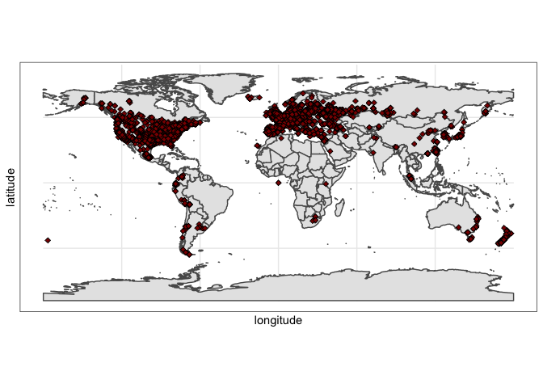

```r
#plot Capsella bursa-pastoris observations with salt data
ggplot(data = world) +
    geom_sf() + geom_point(data = obs, aes(x = longitude, y = latitude), size = 1.5,
        shape = 23, fill = "darkred")
```

The same plot but with the soil points on top because I wanted to see the level of overlap between the two.

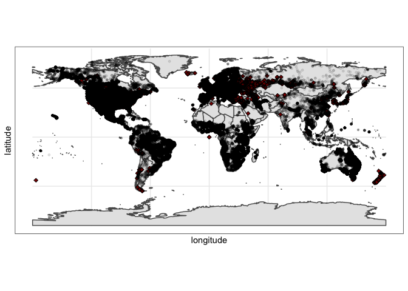

```r
wsalt <- ggplot(data = world) +
    geom_sf() + geom_point(data = obs, aes(x = longitude, y = latitude), size = 1.5,
        shape = 23, fill = "darkred") + geom_point(data = profiles_drop, aes(x = longitude, y = latitude), size = 1, alpha = 0.1, fill = "skyblue4")

wsalt
```

There are many, many more soil data points than iNaturalist observations but they mostly overlap.

### Measuring distance from coast for each iNaturalist observation.

Found [a tutorial](https://dominicroye.github.io/en/2019/calculating-the-distance-to-the-sea-in-r/) on making a raster file of distance from coastlines. The tutorial uses a “fishnet” of points, and works really well for small countries but not all land masses. Instead of a fishnet of points, maybe I can use the observation points of *C. bursa-pastoris*.

**NOTE:** I am suspicious that the transformation step in the following chunk it wrong, so the code is not run in creating the markdown. Specifically, I dont think the shapefile actually has its points translated into UTM.

```r
# Load necessary packages
library(rnaturalearth)
library(sf)
library(lwgeom)

# Pull 50 km resolution map of all land masses, as a simple feature file
#land50 <- ne_download(scale = 50, type = "land", category = "physical", returnclass = "sf")
world <- ne_countries(scale = 50, returnclass = "sf")

#WGS84 equivalent EPSG 4326

# Transform to UTM so it is easier to calculate distances
#land50 <- st_transform(land50, 4326)
world <- st_transform(world, 4326)

#create the points
points <- occr

#convert lat/long point to Simple Feature
points_sf = st_as_sf(points, coords = c("cbp_nodups$longitude", "cbp_nodups$latitude"), crs = 4326)

#only extract the points in the limits of land masses?
cbpmap <- st_intersection(points_sf, world)

#transform world map from polygon shape to line
world <- st_cast(world, "MULTILINESTRING")

#calculation of the distance between the coast and our points
#step takes a bit of time
dist <- st_distance(world, cbpmap)

#distance with unit in meters
head(dist)
```

#### Plotting distance from coast

I haven’t gotten this chunk to plot properly yet.

```r
library(RColorBrewer)

#create a data.frame with the distance and the coordinates of the points
df <- data.frame(dist = as.vector(dist)/1000,
                    st_coordinates(cbpmap))

# check structure
str(df)

# save it just in case
write.table(df, file = "~/Documents/Josephs_lab/worldwide_salt_analysis/dist_coords_cbp_fromCoasts.csv", sep = ",", eol = "\n", quote = FALSE, row.names = FALSE)

# pick cartographically pleasing color palette
col_dist <- brewer.pal(9, "GnBu")

# plot
ggplot(df, aes(X, Y, fill = dist))+ #variables
         geom_tile()+ #geometry
           scale_fill_gradientn(colours = rev(col_dist))+ #colors for plotting the distance
             labs(fill = "Distance (km)")+ #legend name
             theme_void()+ #map theme
              theme(legend.position = "bottom") #legend position
```

### WOSIS chemical profiles

The soil dataset does not explicitly list salinity so I am going to use electrical conductivity which [may be okay.](https://www.nrcs.usda.gov/Internet/FSE_DOCUMENTS/nrcs142p2_053280.pdf)

[Appendix A](https://www.earth-syst-sci-data.net/12/299/2020/) gives the definitions of the values.

On first pass, I want a dataframe that consists of the latitude, longitude, profile_ID (for merging the datasets), and the electrical conductivity measure.

```r
chem_drop <- chem[, c("profile_id", "elco20_value", "elco20_value_avg", "elco20_method", "elco25_value", "elco25_value_avg","elco25_method","elco50_value", "elco50_value_avg", "elco50_method", "elcosp_value", "elcosp_value_avg", "elcosp_method")]

#essentially c-binding the latitude and longitude from "profiles_drop" to the conductivity data, based on profile ID but keeping all of the rows in chem_drop..?
## May or may not be a good idea because I really just want a location and a conductivity...

test_merged <- merge.data.frame(chem_drop, profiles_drop, by="profile_id", all.x = TRUE)
```